# Becas Crema 2.0

Deyban Pérez

March 5, 2016

## Abstract

En la asignación anterior la compañía **Becas Crema** tomó los datos dados por **Control de Estudios** referentes a las renovaciones de beca con la meta de crear una vista minable. El objetivo fue completado y en esta oportunidad nos dispondremos a aplicar algunos algortimos para estimar el **modo de ingreso** de un estudiante que renueva la beca dada sus características.

## Actividades Realizadas

1. Se cargó la vista minable creada en la asignación anterior **minable.csv**.

```r
mydata = read.csv("minable.csv")
```

2. El siguiente paso fue el de selección de características, donde gracias al gran trabajo realizado previamente, todos los tipos de datos fueron categorizados y numerizados en caso de ser posible lo que nos permitió una fácil manipulación de las variables. Así mismo, se removieron aquellas columnas de tipo string y la fila cuyo individuo poseía un **modo de ingreso** tipo 1 (Convenios Nacionales o Internacionales), ya que sólo había una ocurrencia que no aportaba información.

```r
##################################################
#Deleting no important and string features
mydata[,"cIdentidad"] = NULL
mydata[,"fNacimiento"] = NULL
mydata[,"jReprobadas"] = NULL
mydata[,"cDireccion"] = NULL
mydata[,"dHabitacion"] = NULL
mydata[,"oSolicitudes"] = NULL
mydata[,"aEconomica"] = NULL
mydata[,"rating"] = NULL
mydata[,"sugerencias"] = NULL
mydata[,"eCivil"] = NULL
mydata = mydata[-1,] #Deleting outlier
################################################
```

3. Al hacer un análisis de los datos se pueden ver como las clases están desbalanceadas:

```r
sum(mydata[,"mIngreso"] == 0)
```

```
## [1] 71
```

```r
sum(mydata[,"mIngreso"] == 2)
```

```
## [1] 8
```

```r
sum(mydata[,"mIngreso"] == 3)
```

```
## [1] 110
```

```r
prob_0 = 1/sum(mydata[,"mIngreso"] == 0);
prob_2 = 1/sum(mydata[,"mIngreso"] == 2);
prob_3 = 1/sum(mydata[,"mIngreso"] == 3);
```

4. Hacer la separación del **testing** y el **training**, dejando un ochenta por ciento (80 %) de los datos para el **training** y el restante para el **testing**:

```r
################################################
#Calculating probabilities for each element into dataset
prob_0 = 1/sum(mydata[,"mIngreso"] == 0);
prob_2 = 1/sum(mydata[,"mIngreso"] == 2);
prob_3 = 1/sum(mydata[,"mIngreso"] == 3);
###################################################
#Allocating space for vector of probabilities
probabilities = seq(1,nrow(mydata),1)
####################################################
aux0 = 0 #Constant for numebr 0
aux2 = 2 #Constant for number 2
aux3= 3 #Constant for number 3
######################################################
#Filling probabilities for each position in data set
for (i in nrow(mydata))
{
  aux = mydata$mIngreso[i]

  if(aux0 == aux)
  {
    probabilities[i] = prob_0

  }else if(aux2 == aux)
  {
    probabilities[i] = prob_2

  }else if(aux3 == aux)
  {
    probabilities[i] = prob_3
  }

}
########################################################
#Splitting data into training and testing sets
set.seed(777)
sub = sample(nrow(mydata), floor(nrow(mydata) * 0.8), prob = probabilities, replace = F)
training <- mydata[sub, ]
testing <- mydata[-sub, ]
######################################################
```

Las proporciones quedaron de la siguiente manera para el **training**:

```r
sum(training[,"mIngreso"] == 0)
```

```
## [1] 59
```

```r
sum(training[,"mIngreso"] == 2)
```

```
## [1] 7
```

```r
sum(training[,"mIngreso"] == 3)
```

```
## [1] 85
```

Y de la siguiente manera para el **testing**:

```r
sum(testing[,"mIngreso"] == 0)
```

```
## [1] 12
```

```r
sum(testing[,"mIngreso"] == 2)
```

```
## [1] 1
```

```r
sum(testing[,"mIngreso"] == 3)
```

```
## [1] 25
```

Se puede apreciar como las proporciones se siguen manteniendo luego de la separación de los datos.

5. Se generó el modelo para el árbol de decisión usando la función **rpart**, con la **fórmula** (mIngreso ~.) que denota que se queire predecir la caracteŕistica **mIngreso** basándose en las demás características, el parámetro **method** (class) indica que queremos un modelo de clasificación, los parámetros de **control** (minsplit, cp, maxdepth) indican la cantidad mínima de individuos por nodo, el grado de brusquedad en los cambios y la profundidad de árbol respectivamente, estos parámetros fueron permutados hasta que se llegó al mejor resulatdo con los valores que se indican.

[figure not shown]

```r
#######################################################
#Creating decission tree model to predict m Ingreso
tree = rpart(mIngreso ~ ., data = training, method = "class", control = rpart.control(minsplit = 10, cp = 0.001, maxdepth = 3))
#Plotting model
fancyRpartPlot(tree)
```

6. Para evaluar el modelo se realizó una matriz de confusión y se calculó la tasa de error y de fallos evaluando la diagonal, tal como s emeustra a continuación:

```r
##############################################################################
#Creating confusion matrix tree
confusionMatrixTree = table(testing$mIngreso, predict(tree, newdata = testing,type = "class"))
#Visualizing Confusion matriz
confusionMatrixTree
```

```
##
##      0  2  3
##   0  7  0  5
##   2  0  0  1
##   3  9  1 15
```

```r
##############################################################################
#Calculating hit rate tree
hitRateTree = ((confusionMatrixTree[1,1] + confusionMatrixTree[2,2] + confusionMatrixTree[3,3]) / nrow(testing)) *100
#Visualizing hit rate tree
hitRateTree
```

```
## [1] 57.89474
```

```r
##############################################################################
#Calculating error rating tree
errorRateTree = 100 - hitRateTree
#Visualizing error rate
errorRateTree
```

```
## [1] 42.10526
```

```r
##############################################################################
```

7. Se reacomodan los parámetro a ser pasados para el algoritmo de **K-Vecinos**, para esto se debió normalizar las columnas y eliminar las etiquetas de los conjuntos de **entrenamiento** (training) y **prueba** (training).

```r
##############################################################################
# Beginning k nearest neighbor model
##############################################################################
#Extracting labels for traing and test
trainingLabels = training$mIngreso
testingLabels = testing$mIngreso
##############################################################################
#Deleting rows to be predicted
trainingClasificationRules = training
testingClasificationRules = testing
auxPCA = training
training[,"mIngreso"] = NULL
testing[,"mIngreso"] = NULL
##############################################################################
#Normalizing training and testing sets
training_norm = as.data.frame(lapply(training[1:ncol(training)], normalize))
testing_norm = as.data.frame(lapply(testing[1:ncol(testing)], normalize))
##############################################################################
```

8. Se generó el modelo de **K-Vecinos** haciendo uso de la función **knn**, pasando los conjutnos de prueba y entrenamiento **normalizados** y el parámetro **cl** que indica la vecindad a preguntar **14** tomando como medida la raíz cuadrada del numero total de individuos en el data set (189) que suele ser la medida que mejor se comporta teoricamente.

```r
##############################################################################
#Generating knn model
mydata_pred <- knn(train = training_norm, test = testing_norm, cl = trainingLabels, k=14)
##############################################################################
```

9. Evaluando el modelo de **K-Vecinos** de igual manera que en **árboles de decisión** se utilizó una matriz de confusión y se calcularon las tasas de aciertos y fallos.

```r
##############################################################################
#Creating confusion matrix
confusionMatrixK = table(testingLabels, mydata_pred)
#Visualizing Confusion matriz
confusionMatrixK
```

```
##              mydata_pred
## testingLabels  0  2  3
##             0  8  0  4
##             2  0  0  1
##             3  4  0 21
```

```r
#############################################################################
#Calculating hit rate
hitRateK = ((confusionMatrixK[1,1] + confusionMatrixK[2,2] + confusionMatrixK[3,3]) / nrow(testing)) *100
#Visualizing hit rate
hitRateK
```

```
## [1] 76.31579
```

```r
##############################################################################
#Calculating error rating
errorRateK = 100 - hitRateK
#Visualizing error rate
errorRateK
```

```
## [1] 23.68421
```

```r
##############################################################################
```

10. Se generó el modelo de **Reglas de Clasificación** haciendo uso de la función **JRip** provista por la interfaz **RWeka**, para ello debimos transformar los daros como se muestra a continuación:

```r
##############################################################################
# Beginning clasification rules
###############################################################################
#Transforming column into factor type
trainingClasificationRules$mIngreso = as.factor(trainingClasificationRules$mIngreso)
testingClasificationRules$mIngreso = as.factor(testingClasificationRules$mIngreso)
###############################################################################
```

11. Se generó el modelo de **Reglas de clasificación** como se muestra a continuación:

```r
###############################################################################
#Generating Clasification Rules model
rules = JRip(formula = mIngreso ~ ., data = trainingClasificationRules)
##############################################################################
```

12.- De igual manera que en los modelos anteriores, se evaluó el modelo haciendo uso de una matriz de confusión, y se calcularon las tasas de aciertos y fallos, tal cómo se muestra a continuación:

```r
##############################################################################
#Creating confusion matrix
confusionMatrixClasification = table(testingClasificationRules$mIngreso, predict(rules, newdata = testingClasificationRules,type = "class"))
#Visualizing Confusion matriz
confusionMatrixClasification
```

```
##
##      0  2  3
##   0  5  1  6
##   2  0  0  1
##   3 10  1 14
```

```r
################################################################################
#Calculating hit rate
hitRateClasification = ((confusionMatrixClasification[1,1] + confusionMatrixClasification[2,2] + confusionMatrixClasification[3,3]) / nrow(testing)) *100
#Visualizing hit rate
hitRateClasification
```

```
## [1] 50
```

```r
#################################################################################
#Calculating error rating
errorRateClasification = 100 - hitRateClasification
#Visualizing error rate
errorRateClasification
```

```
## [1] 50
```

```r
#################################################################################
#END
```

## Comparación de Modelos

Para comparar los modelos podemos volver a visualizar las diferentes matrices de confusíon y las tasas de aciertos y fallas de los distintos modelos:

#### Árbol de decision

```r
confusionMatrixTree
```

```
##
##      0  2  3
##   0  7  0  5
##   2  0  0  1
##   3  9  1 15
```

```r
hitRateTree
```

```
## [1] 57.89474
```

```r
errorRateTree
```

```
## [1] 42.10526
```

#### K-Vecinos

```r
confusionMatrixK
```

```
##              mydata_pred
## testingLabels  0  2  3
##             0  8  0  4
##             2  0  0  1
##             3  4  0 21
```

```r
hitRateK
```

```
## [1] 76.31579
```

```r
errorRateK
```

```
## [1] 23.68421
```

#### Reglas de Clasificación

```r
confusionMatrixClasification
```

```
##
##      0  2  3
##   0  5  1  6
##   2  0  0  1
##   3 10  1 14
```

```r
hitRateClasification
```

```
## [1] 50
```

```r
errorRateClasification
```

```
## [1] 50
```

Se puede ver como el modelo que presenta mejor porcentaje de acierto es **K-Vecinos**, seguido por **Árboles de decisión** y **Reglas de Clasificación** respectivamente. Aunque el modelo de **k-Vecinos** da un porcentaje de acierto por encima de setenta po ciento (70%), me parece que no e sun buen modelo debido a que las características no definen bein el problema y se tiene un conjunto de ocurrencias muy pequeño para el entrenamiento, debido a eso los otros dos algoritmos presentan un probe desempeño, ya que se hace difícil estimar, cómo se puede observar en el siguiente gráfico de **Anáilis de Componentes Principales** las características no representan de buena manera a todo el espacio.

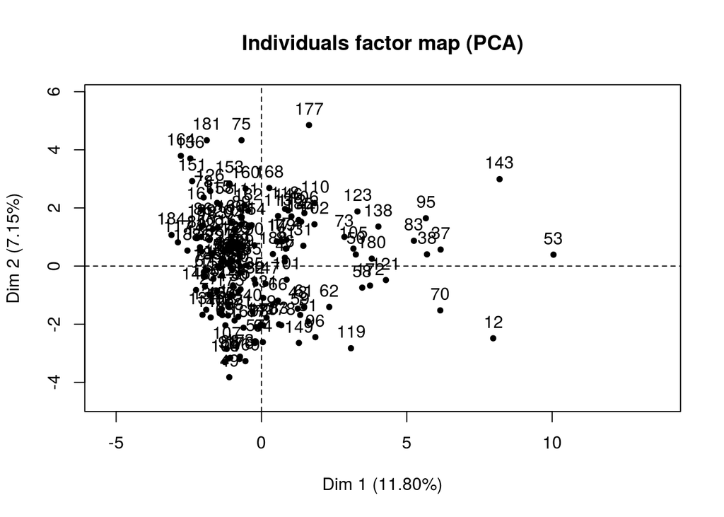

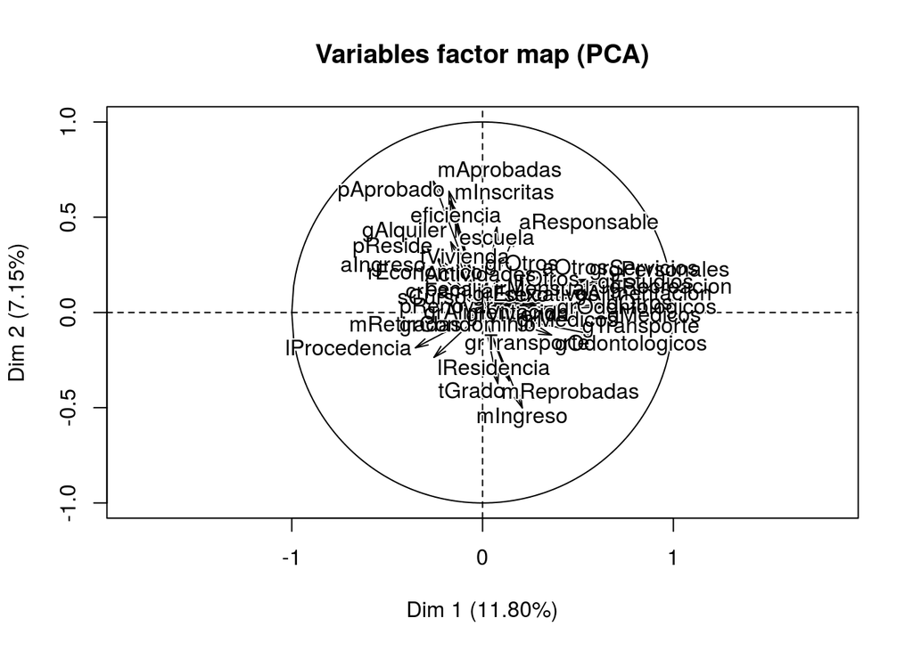

```
## **Results for the Principal Component Analysis (PCA)**
## The analysis was performed on 151 individuals, described by 43 variables
## *The results are available in the following objects:
##
##    name               description
## 1  "$eig"             "eigenvalues"
## 2  "$var"             "results for the variables"
## 3  "$var$coord"       "coord. for the variables"
## 4  "$var$cor"         "correlations variables - dimensions"
## 5  "$var$cos2"        "cos2 for the variables"
## 6  "$var$contrib"     "contributions of the variables"
## 7  "$ind"             "results for the individuals"
## 8  "$ind$coord"       "coord. for the individuals"
## 9  "$ind$cos2"        "cos2 for the individuals"
## 10 "$ind$contrib"     "contributions of the individuals"
## 11 "$call"            "summary statistics"
## 12 "$call$centre"     "mean of the variables"
## 13 "$call$ecart.type" "standard error of the variables"
## 14 "$call$row.w"      "weights for the individuals"
## 15 "$call$col.w"      "weights for the variables"
```

```r
PCA(auxPCA)
```